# Retail Customer Lifetime Value & Segmentation

Analysis report — generated by `make all`, do not edit by hand

## 1 Headline

CLV figures scale linearly with the assumed gross margin. The dataset contains revenue only, no cost data.

| Metric | Value |
| --- | --- |
| Customers | 4331 |
| Invoices | 18455 |
| Products | 3864 |
| Countries | 37 |
| Revenue (12 months) | £8,389,699 |
| Average order value | £454.6 |

| Metric | Value |
| --- | --- |
| Customers modelled | 4,331 |
| Revenue in window | £8,389,699 |
| Segments (k chosen by silhouette) | 2 |
| Predicted portfolio CLV (52 weeks) | £6.9M |
| Customers with non-zero predicted CLV | 1,989 (46%) |
| Share of CLV held by Segment 2 | 72% |
| Gross margin assumption | 50% (assumed) |

## 2 Data cleaning

[output not shown]

Four rules, in order: drop rows with no `CustomerID`; drop rows with no `Description`; drop cancellations (quantity or price `<= 0`, or a `C`-prefixed invoice number); drop the *entire* invoice containing a quantity outlier above a Tukey outer fence. Dropping only the negative leg of a cancelled order would leave the original in place.

## 3 Segments

Segment 1 is always the lowest-value group by construction — k-means returns clusters in arbitrary order, so labels are remapped by ascending median spend. Without that, any statement of the form “cluster 3 is the most valuable” would be unfalsifiable.

| segment | customers | share_of_base | recency_median | frequency_median | monetary_median | aov_median | revenue_share | clv_total | clv_median | clv_share_of_total |
| --- | --- | --- | --- | --- | --- | --- | --- | --- | --- | --- |
| Segment 1 | 2620 | 0.6049411 | 94.5 | 1 | 353.565 | 225.6850 | 0.1362469 | 1954049 | 0.000 | 0.2841222 |
| Segment 2 | 1711 | 0.3950589 | 17.0 | 5 | 2062.060 | 370.0723 | 0.8637531 | 4923446 | 1201.107 | 0.7158778 |

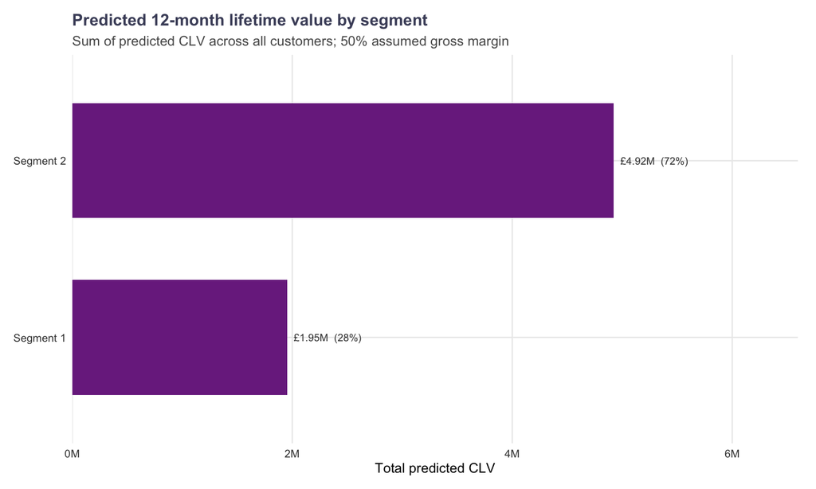

Predicted lifetime value by segment.

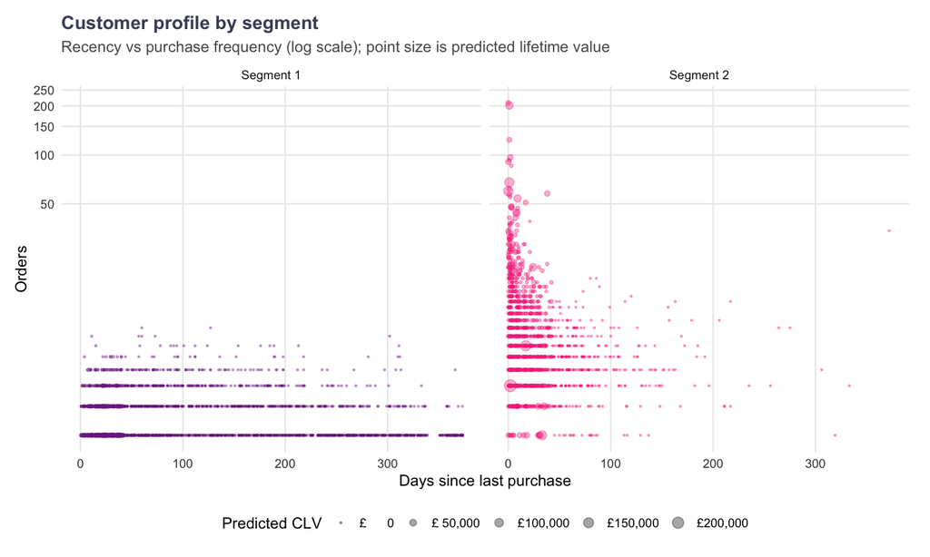

Customer profile by segment; point size is predicted CLV.

## 4 Choosing k

The three standard criteria disagree on this data, which is stated rather than averaged away.

k-selection criteria. Policy: candidates must be stable (bootstrap ARI >= 0.90); among stable candidates take the silhouette optimum.

| Criterion | Prefers | Note |
| --- | --- | --- |
| Elbow (maximum curvature) | 4 | heuristic |
| Silhouette | 2 | chosen: stable and silhouette-optimal |
| Gap statistic | 2 | depends on the null distribution |
| Bootstrap stability | 2 | ARI >= 0.90 required |

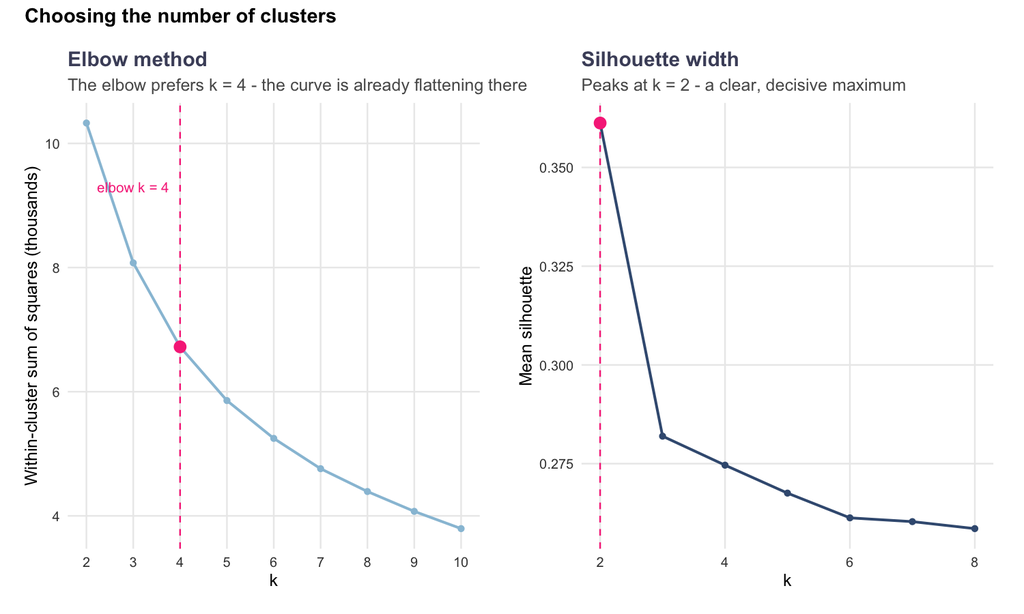

Elbow and silhouette diagnostics.

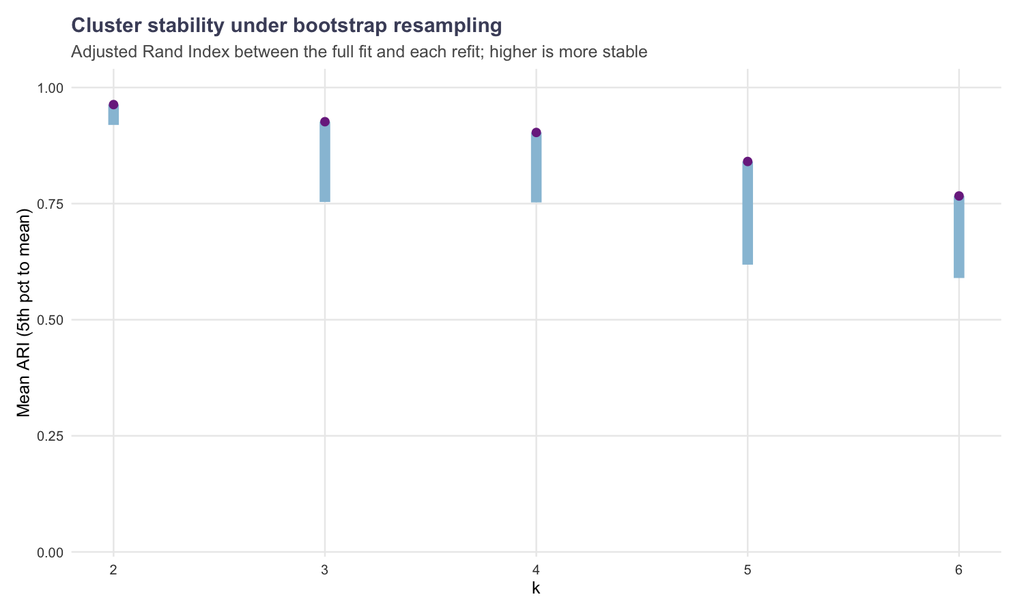

Cluster stability across bootstrap resamples.

## 5 Validation

`between_SS/total_SS` is an in-sample statistic: it measures how well k-means fit the data it was given, and it is monotone in k, so it cannot validate anything. These are the out-of-sample diagnostics.

The partition survives removing 30% of the customers essentially unchanged.

| Check | Value |
| --- | --- |
| Within-cluster SS (in-sample) | 0.404 |
| Within-cluster SS (70% train split) | 0.414 |
| Silhouette (full data) | 0.361 |
| Silhouette (held out, 30% unseen customers) | 0.339 |
| ARI, train fit vs full fit | 0.996 |
| ARI, mean across 100 bootstrap resamples | 0.963 |

## 6 Customer retention and CLV

CLV is expected future activity x observed purchase rate x average order value x assumed margin. Every factor is either directly observed or comes from a fitted curve:

- **purchase rate** — orders per week of *observed active lifetime* (first purchase to last purchase), not per week of calendar tenure.
- **remaining life** — the Kaplan-Meier curve, conditioned on the customer having survived to their current age: `int_a^{a+H} S(u) du / S(a)`.
- **churn** — a customer whose last purchase is older than the censoring window has already churned and is worth zero.

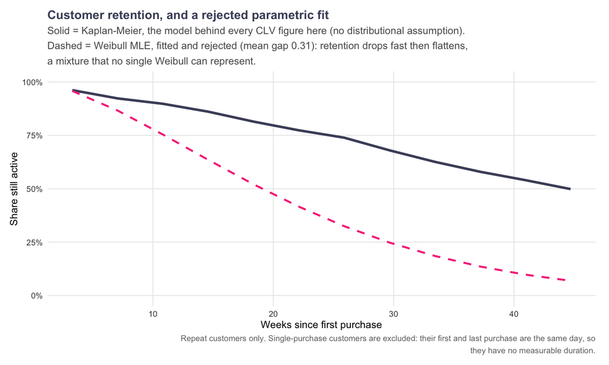

Retention: the Kaplan-Meier model used for CLV, and a rejected parametric fit.

### 6.1 The Weibull fit was rejected

The dashed line above is a Weibull maximum-likelihood fit, computed and then discarded. It disagrees with the non-parametric estimate by a mean absolute 0.31 in survival probability, predicting 7% still active where Kaplan-Meier says 50%.

Single-purchase customers are excluded from the lifetime fit: their first and last purchase are the same day, so they have no measurable duration.

Segment profiles. A churned customer (last purchase older than the censoring window) has a predicted CLV of zero by construction, which is why the dormant segment’s median is £0.

| segment | customers | share_of_base | recency_median | frequency_median | monetary_median | aov_median | revenue_share | clv_total | clv_median | clv_share_of_total |
| --- | --- | --- | --- | --- | --- | --- | --- | --- | --- | --- |
| Segment 1 | 2620 | 0.6049411 | 94.5 | 1 | 353.565 | 225.6850 | 0.1362469 | 1954049 | 0.000 | 0.2841222 |
| Segment 2 | 1711 | 0.3950589 | 17.0 | 5 | 2062.060 | 370.0723 | 0.8637531 | 4923446 | 1201.107 | 0.7158778 |

## 7 Where the value sits

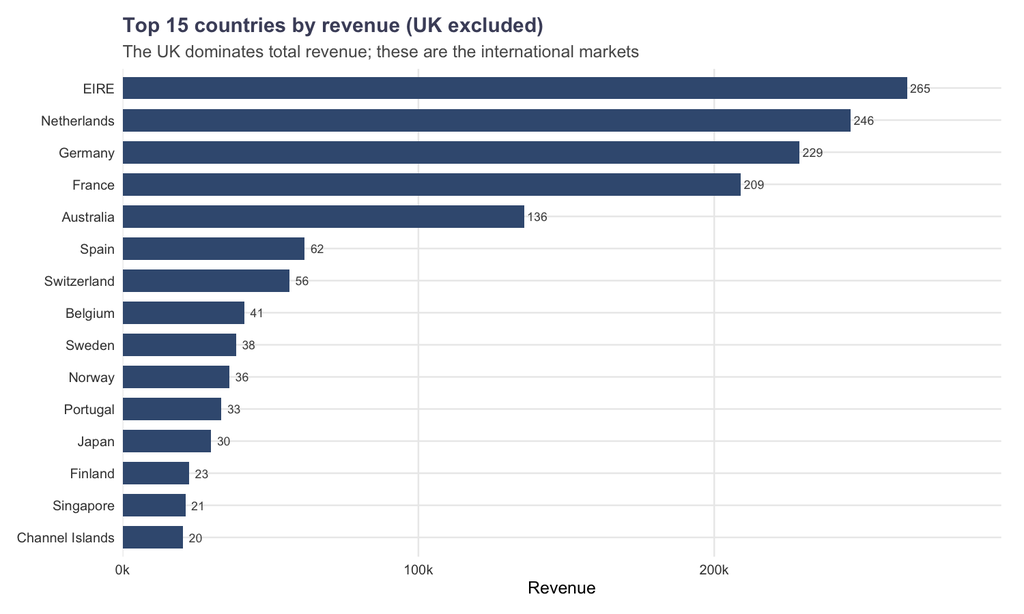

Revenue by country, UK excluded. The UK dominates total revenue.

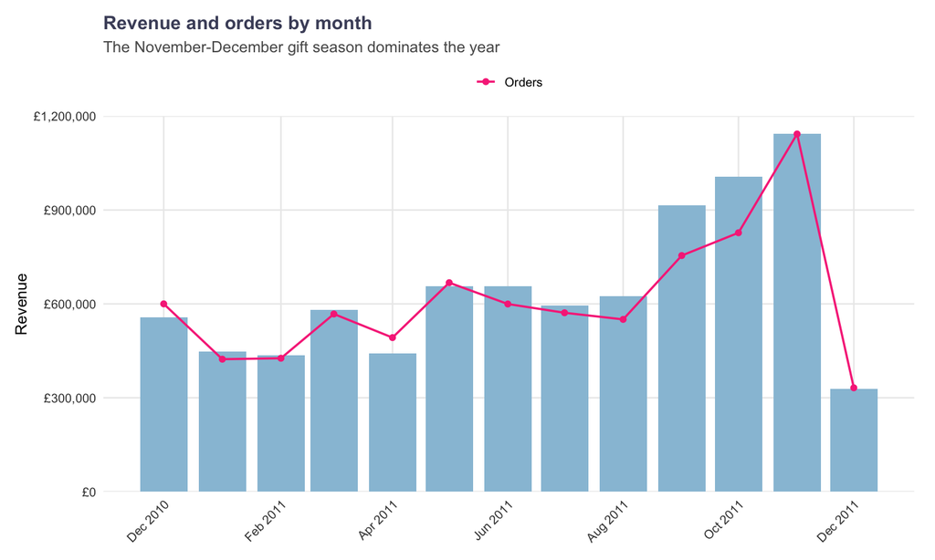

Revenue and orders by month; the November-December gift season dominates the year.

Revenue is highly seasonal and domestic. Segment 2 is 39.5% of customers but 86% of revenue; the dormant segment has a median predicted CLV of zero.

## 8 Limitations

1. **The gross margin is assumed, not measured.** The dataset has revenue only. Every CLV figure scales linearly with it.
2. **CLV is not validated against outcomes.** The dataset ends, so there is no holdout period to check predictions against realised spend. This is the first item in the README’s “what I’d do next”.
3. **k=2 is coarse.** The elbow method prefers k=4, which gives four clean tiers. k=2 ships because that is what the silhouette supports.
4. **The wholesale channel is largely absent.** Customers with no `CustomerID` were dropped from customer-level segmentation; they carry ~17% of revenue and include bulk trade accounts, so “Champions” describes registered retail buyers only.
5. **Single-purchase customers have no measurable lifetime**, so the retention curve is estimated from repeat customers only (66% of the base).

## 9 Reproducing this report

| Step | Command |
| --- | --- |
| Restore the pinned library | renv::restore() |
| Run the pipeline | make all |
| Run the tests | make test |
| This report | targets::tar_make(names = ‘report’) |

Every figure and table in this document is generated. `make all` recomputes them; nothing is transcribed by hand.

Generated by `R/06_report.R::render_report()`. Do not edit — regenerate instead.